# Plotting

Pier Lorenzo Paracchini  
20.09.2017

### Plotting Systems in R

Graphics and plotting are used for primarily two reasons: exploratory data analysis (EDA) and presenting results.

R provides excellent graphing capabilities through different plotting systems

- **Base Plotting System**, the traditional R plotting system automatically installed (`graphic` package - base R)
  - quite powerful and able to produce many kinds of graphics (+)
  - quite complex to use if more control over the details of graphic output is needed (-)
- **ggplot2**, an implementation of the '[grammar of graphic](http://ggplot2.org/resources/2007-vanderbilt.pdf)' (`ggplot2` package - non base R)
- others like **Lattice Graphics**, **HTML widgets**…

### Base Plotting System: The R Graphics Package

The **plotting process**:

- Start with blank canvas, then
- Add a plot function (or similar)
- Use **1..*** **annotation functions** to
  - add/modify what's on the canvas
    - e.g. `text`, `lines`, `points`, `axis`

Some characteristics…

- Convenient, mirrors how we think of building plots and analyzing data (+)
- Can't go back once plot has started (i.e. to adjust margins); need to plan in advance (-)
- Plot is just a series of R commands

### Base Plotting System: Histogram

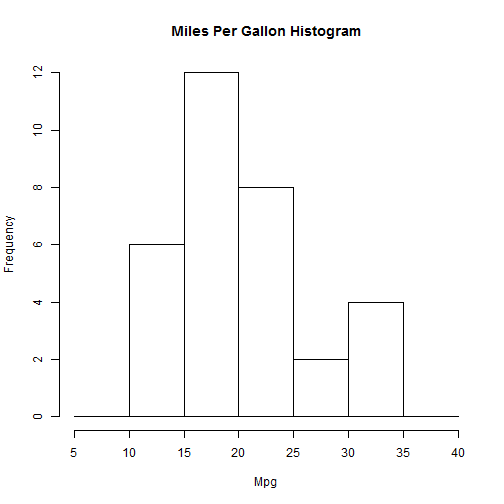

```r
# graphics::hist()
hist(mtcars$mpg,
     breaks = c(5,10,15,20,25,30,35,40),
     main = "Miles Per Gallon Histogram", xlab = "Mpg")
```

### Base Plotting System: Scatterplot

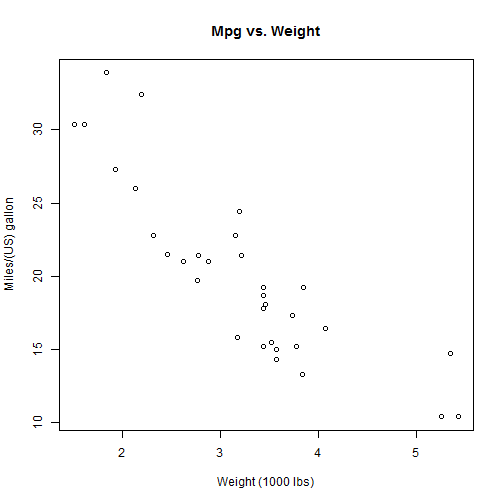

```r
# graphics::plot(x, y, ...)
plot(x = mtcars$wt, y = mtcars$mpg,
     main = "Mpg vs. Weight",
     xlab = "Weight (1000 lbs)",
     ylab = "Miles/(US) gallon")
```

### Base Plotting System: Boxplot

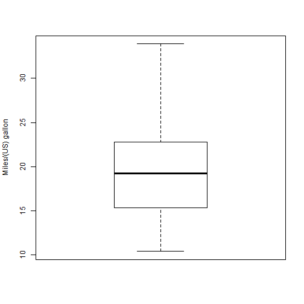

```r
# graphics::boxplot()
boxplot(mtcars$mpg, ylab = "Miles/(US) gallon")
```

### Base Plotting System: Scatterplot Ext'd

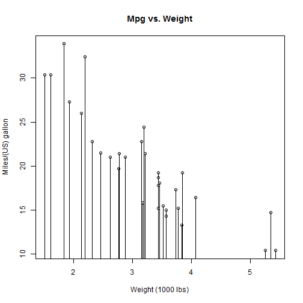

```r
# graphics::plot(x, y, ...)
plot(x = mtcars$wt, y = mtcars$mpg,
     main = "Mpg vs. Weight",
     xlab = "Weight (1000 lbs)",
     ylab = "Miles/(US) gallon")
lines(x = mtcars$wt, y = mtcars$mpg, type = "h")
```

### Base Plotting System: Example

**Add more capability with more commands…**

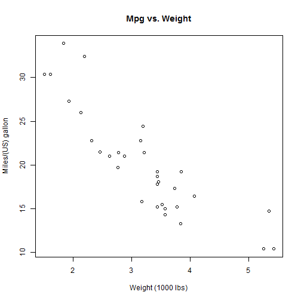

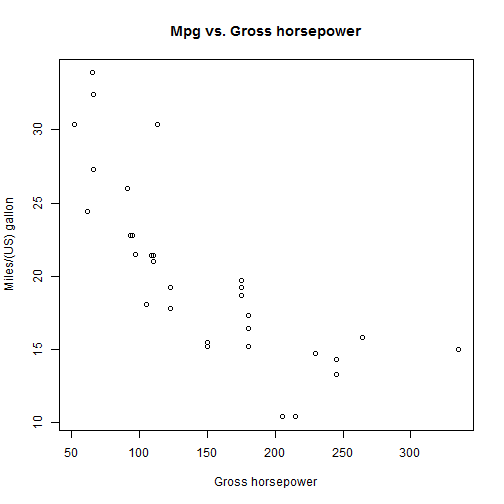

```r
# graphics::plot(x, y, ...)
with(mtcars,{
    plot(x = mtcars$wt, y = mtcars$mpg,  main = "Mpg vs. Weight",
     xlab = "Weight (1000 lbs)", ylab = "Miles/(US) gallon")
    plot(x = mtcars$hp, y = mtcars$mpg,  main = "Mpg vs. Gross horsepower",
     xlab = "Gross horsepower", ylab = "Miles/(US) gallon")
})
```

### Hands-On (10 min)

```r
library(swirl)
swirl()
#.....
# Select the "R Programming" entry
# Select the "Base Graphics" entry [15]
```

### Plotting: Advanced graphics

### **`ggplot2` graphic system**

- [examples](http://www.r-graph-gallery.com/portfolio/ggplot2-package/)
- Theory:
  - “[Basic plotting with R and ggplot2](https://pparacch.github.io/2017/07/06/plotting_in_R_ggplot2_part_1.html)”, Part 1
  - “['ggplot2', essential concepts](https://pparacch.github.io/2017/07/14/plotting_in_R_ggplot2_part_2.html)”, Part 2
  - “[Guidelines for good plots](https://pparacch.github.io/2017/07/18/plotting_in_R_ggplot2_part_3.html)”, Part 3
  - “[How to work with maps](https://pparacch.github.io/2017/08/28/plotting_in_R_ggplot2_part_4.html)”, Part 4

### **Plotly R Library**

Plotly's R graphing library makes interactive, publication-quality graphs online.

- [Documentation & Examples](https://plot.ly/r/)